# NPTEL

```python
import pandas as pd
import numpy as np
import math
```

```python
path="E:\\New folder\\IBM-313 Marks.xlsx"
table=pd.read_excel(path)
table
```

|  | S.No. | MTE (25) | Mini Project (25) | Total (50) | ETE (50) | Total |
| --- | --- | --- | --- | --- | --- | --- |
| 0 | 1 | 5.00 | 20 | 25.00 | 12.0 | 37.00 |
| 1 | 2 | 11.05 | 20 | 31.05 | 26.0 | 57.05 |
| 2 | 3 | 8.10 | 20 | 28.10 | 14.0 | 42.10 |
| 3 | 4 | 6.00 | 10 | 16.00 | 13.0 | 29.00 |
| 4 | 5 | 11.35 | 20 | 31.35 | 17.0 | 48.35 |
| ... | ... | ... | ... | ... | ... | ... |
| 74 | 75 | 12.05 | 10 | 22.05 | 20.0 | 42.05 |
| 75 | 76 | 12.25 | 10 | 22.25 | 28.0 | 50.25 |
| 76 | 77 | 1.75 | 10 | 11.75 | NaN | 0.00 |
| 77 | 78 | 3.00 | 10 | 13.00 | NaN | 0.00 |
| 78 | 79 | 5.80 | 10 | 15.80 | 12.0 | 27.80 |

79 rows × 6 columns

```python
x=table['Total']
np.mean(x)
```

```
46.90632911392405
```

```python
np.median(x)
```

```
45.0
```

```python
import statistics
statistics.mode(x)
```

```
48.35
```

```python
a=np.array([1,2,3,4,5])
p=np.percentile(a,50)#return 50th percentile
print(p)
```

```
3.0
```

```python
k=['Ram',65,2.5]
print(k)
```

```
['Ram', 65, 2.5]
```

```python
for i in k:
    print(i)
```

```
Ram
65
2.5
```

```python
a=np.array([1,2,3,4,5])
q1=np.percentile(a,25)
q1
```

```
2.0
```

```python
q2=np.percentile(a,50)
q2
```

```
3.0
```

```python
q3=np.percentile(a,75)
q3
```

```
4.0
```

```python
IQ=q3-q1 #Inter-Quartile range
IQ
```

```
2.0
```

```python
np.var(x)#population variance
```

```
262.78147892965876
```

```python
import statistics
statistics.pstdev(x)#population standard deviation
```

```
16.210536046955966
```

```python
statistics.stdev(x)#sample standard deviation
```

```
16.31411880088133
```

```python
np.std(x)#population standard deviation
```

```
16.210536046955966
```

```python
from scipy.stats import skew
skew(x)#To find skewness of the data
```

```
0.10226407464884266
```

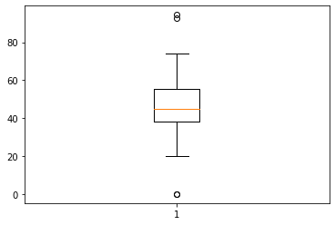

```python
from matplotlib import pyplot
pyplot.boxplot(x)
pyplot.show() #here circle represent that some data are out-layred means some data are beyond maximum and some below minimum bound
```

Binomial Distribution

A Gallup survey found that 65% of all financial consumers were very satisfied with their primary financial institution. Suppose that 25 financial consumers are sampled and if the Gallup survey result still holds true today, what is the probability that exactly 19 are very satisfied with their primary financial institution?

```python
import scipy
from scipy.stats import binom
```

```python
print(binom.pmf(k=19,n=25,p=0.65))#pmf -> probability mass function,cuz here we want to knw for exact 19 students
#Jo mere x hai wo yaha k hai
```

```
0.090777998593228
```

According to the U.S. Census Bureau, approximately 6% of all workers in Jackson, Mississippi, are unemployed. In conducting a random telephone survey in Jackson, what is the probability of getting two or fewer unemployed workers in a sample of 20?

```python
binom.cdf(2,20,0.06)#cdf->cummulative distribution function,cuz here we want P(0+1+2)or P(<=2)
```

```
0.8850275957378549
```

Poisson Distribution

```python
from scipy.stats import poisson
```

```python
poisson.pmf(3,2)# x=3, lamda=mean=variance=2
```

```
0.18044704431548356
```

Bank customers arrive randomly on week days afternoon at an average of 3.2 customers every 4 minutes. What is the probability of exactly 5 customers in a 4 minute interval on a week day afternoon?

```python
poisson.pmf(5,3.2) #P(X=5)
```

```
0.11397938346351824
```

```python
#Bank customers arrive randomly on week days afternoon at an average of 3.2 customers every 4 minutes.
#What is the probability of having more than 7 customers in a 4 minute interval on a week day afternoon?
```

```python
prob=poisson.cdf(7,3.2) #P(X>7)=1−P(X=0)−P(X=1)−P(X=2)−P(X=3)−P(X=4)−P(X=5)−P(X=6)−P(X=7)
#CDF considers from (0-X)
prob
```

```
0.9831701582510425
```

```python
prob_x_more_than_7=1-prob
prob_x_more_than_7
```

```
0.01682984174895752
```

Bank customers arrive randomly on week days afternoon at an average of 3.2 customers every 4 minutes. What is the probability of exactly 10 customers in 8 minute interval on a week day afternoon?

```python
poisson.pmf(10,6.4) #P(X=10) and to match the unit=8mins will multiply 3.2*2/4*2=6.4/8 mins
```

```
0.052790043854115495
```

Uniform Distribution

Suppose the amount of time it takes to assemble a plastic module ranges from 27 to 39 seconds and that assembly times are uniformly distributed. Describe the distribution. What is the probability that a given assembly will take between 30 and 35 seconds?

```python
U=np.arange(27,40,1)
U
```

```
array([27, 28, 29, 30, 31, 32, 33, 34, 35, 36, 37, 38, 39])
```

```python
from scipy.stats import uniform
uniform.mean(loc=27,scale=12) #scale =39-27
```

```
33.0
```

```python
uniform.cdf(np.arange(30,36,1),loc=27,scale=12)
```

```
array([0.25      , 0.33333333, 0.41666667, 0.5       , 0.58333333,
       0.66666667])
```

```python
Prob=0.66666667-0.25
Prob
```

```
0.41666667
```

According to the National Association of Insurance Commissioners, the average annual cost for automobile insurance in the United States in a recent year was 691. Suppose automobile insurance costs are uniformly distributed in the United States with a range from 200 to 1,182. What is the standard deviation of this uniform distribution?

```python
uniform.mean(loc=200,scale=982)
```

```
691.0
```

```python
print(math.sqrt(982**2/12)) #Use formula of sqrt(variance) in Uniform Distribution
```

```
283.4789821721062
```

```python
uniform.std(loc=200,scale=982)
```

```
283.4789821721062
```

Normal Distribution

```python
from scipy.stats import norm
```

```python
val=68 #x=68
mean=65.5
sd=2.5 #std
norm.cdf(val,mean,sd)
```

```
0.8413447460685429
```

cdf(x>val)

```python
print(1-norm.cdf(val,mean,sd))
```

```
0.15865525393145707
```

cdf(val1<x<val2)

```python
norm.cdf(68,mean,sd)-norm.cdf(63,mean,sd)
```

```
0.6826894921370859
```

What is the probability of obtaining a score greater than 700 on a GMAT test that has a mean of 494 and a standard deviation of 100? Assume GMAT scores are normally distributed.

P(x > 700 | μ = 494 and σ = 100) = ?

```python
prob=norm.cdf(700,494,100)
prob
```

```
0.9803007295906231
```

```python
actual_prob=1-prob
actual_prob
```

```
0.019699270409376912
```

What is the probability of obtaining a score greater than 550 or less?

```python
norm.cdf(550,494,100)
```

```
0.712260281150973
```

What is the probability of obtaining a score between 300 and 600 on GMAT Exam?

```python
norm.cdf(600,494,100)-norm.cdf(300,494,100)
```

```
0.8292378553956377
```

```python
norm.ppf(0.95)# probablity function for finding a given area
```

```
1.6448536269514722
```

```python
norm.ppf(1-0.6772)#cuz we are moving letf side
```

```
-0.45988328292440145
```

Hypergeomertic Distribution

Assume that 18 major computer manufacturing companies operate in the United States and that 12 are located in Silicon Valley of California. If three of these companies are randomly selected from the list, what is the probability that none of the selected companies is located in Silicon Valley of California?

```python
from scipy.stats import hypergeom
pval=hypergeom.cdf(0,18,3,12) #sf is survavl function sf=1-cdf P(X=3)
#(x,N,n,A)
pval
```

```
0.024509803921568606
```

```python
actual=1-pval #P(X=0) mtlb humne prob nikala X=3 ke liye usme se 1-p(X) kiye to P(X=0) ke liye aaya
actual
```

```
0.9754901960784313
```

A western city has 18 police officers eligible for promotion. Eleven of the 18 are Hispanic. Suppose only five of the police officers are chosen for promotion and that one is Hispanic. If the officers chosen for promotion had been selected by chance alone, what is the probability that one or fewer of the five promoted officers would have been Hispanic?

```python
pval=hypergeom.cdf(1,18,5,11)
pval
```

```
0.04738562091503275
```

Exponential Distribution

A manufacturing firm has been involved in statistical quality control for several years. As part of the production process, parts are randomly selected and tested. From the records of these tests, it has been established that a defective part occurs in a pattern that is Poisson distributed on the average of 1.38 defects every 20 minutes during production runs. Use this information to determine the probability that less than 15min will elapse between any two defects.

```python
mean_of_expo=1/1.38# cuz lamda is given in Poissons form
mean_of_expo
```

```
0.7246376811594204
```

```python
from scipy.stats import expon
```

```python
expon.cdf(0.75,0,(1/1.38)) #15/20 =0.75,loc=0
```

```
0.6447736190750485
```